# Causal Inference - Exercise valid adjustment sets

Michael Knaus

SoSe 25

These are the goals of today:

- Find valid adjustment sets in DAGs

# DAG inspired by Figure 3.8 in “The Primer”

We do first everything manually and then check it using `dagitty`.

## Define the DAG

```
if (!require("dagitty")) install.packages("dagitty", dependencies = TRUE); library(dagitty)
if (!require("ggdag")) install.packages("ggdag", dependencies = TRUE); library(ggdag)
```

First, we need to define the DAG. To this end, we define a new `dagitty` object that

- defines the variables and their position in a (imaginary) cartesian coordinate system
- the directed edges between the variables

```
# DAG
G1 = dagitty('dag{ B [pos = "0,2"]
                      C [pos = "2,2"]
                      A [pos = "-1,2"]
                      D [pos = "1,1"]
                      W [pos = "0,0"]
                      M [pos = "1,0"]
                      Y [pos = "2,0"]
                      E [pos = "0,-1"]
                      F [pos = "2,-1"]
                      B -> W
                      B -> D
                      C -> D
                      C -> Y
                      A -> W
                      D -> W
                      D -> Y
                      W -> M
                      W -> E
                      Y -> F
                      M -> Y}')
```

Use `ggdag` to plot the DAG:

```
ggdag(G1) + theme_dag()
```

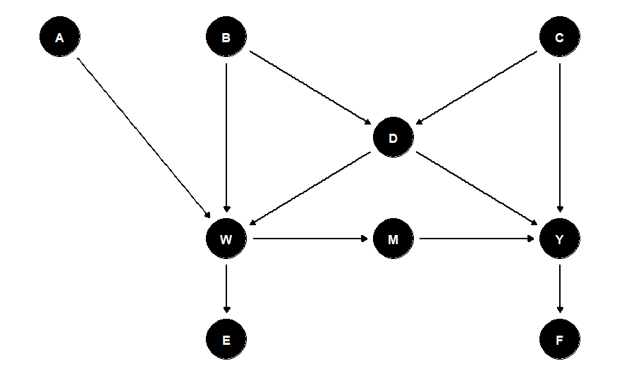

## Structural causal model

First we read off the structural causal model:

- $A := f_A(U_A)$
- $B := f_B(U_B)$
- $C := f_C(U_C)$
- $D := f_D(B,C,U_D)$
- $E := f_E(W,U_E)$
- $F := f_F(Y,U_F)$
- $M := f_M(W,U_M)$
- $W := f_W(A,B,D,U_W)$
- $Y := f_Y(C,D,M,U_Y)$

## Parent Adjustment manually

Definition: $X$ contains **all parents of $W$**

The valid adjustment set derived from parent adjustment is $X = \{A,B,D\}$

Note that parent adjustment always results in only one adjustment set.

## Backdoor criterion

Definition:

- $X$ contains **no descendant of $W$**
- **$X$ blocks every path** between $W$ and $Y$ that contains an arrow into $W$

First part rules out adjusting for variables $E,M,Y,F$

Second part can be fulfilled by several adjustment sets. To derive them, first collect the backdoor paths:

- WDY: $W \leftarrow D \rightarrow Y$, open but closed by $D$
- WBDY: $W \leftarrow B \rightarrow D \rightarrow Y$, open but blocked/closed by $\{B\},\{D\},\{B,D\}$
- WDCY: $W \leftarrow D \leftarrow C \rightarrow Y$, open but closed by $\{C\},\{D\},\{C,D\}$
- WBDCY: $W \leftarrow B \rightarrow D \leftarrow C \rightarrow Y$, closed/blocked by $\{\},\{B\},\{C\},\{B,C\},\{B,D\},\{C,D\},\{B,C,D\}$

Additionally I could always condition on $A$ without opening or closing a path

The valid adjustment sets derived from the backdoor criterion are therefore $\{C,D\},\{B,D\},\{B,C,D\},\{A,C,D\},\{A,B,D\},\{A,B,C,D\}$

## Adjustment Criterion

Definition:

- $X$ contains **no descendant of any node on a directed path** from $W$ to $Y$ except for descendants of $W$ that are not on a directed path from $W$ to $Y$
- **$X$ blocks all non-directed paths** from $W$ to $Y$

First part rules out adjusting for variables $M,Y,F$.

Second part identical to BC but additionally conditioning on $E$ is allowed.

$\{C,D\},\{B,D\},\{B,C,D\},\{A,C,D\},\{A,B,D\},\{A,B,C,D\},\{C,D,E\},\{B,D,E\},\{B,C,D,E\},\{A,C,D,E\},\{A,B,D,E\},\{A,B,C,D,E\}$

## Document all paths between $W$ and $Y$

```
paths(G1, "W", "Y")
```

```
$paths
[1] "W -> M -> Y"           "W <- B -> D -> Y"      "W <- B -> D <- C -> Y" "W <- D -> Y"           "W <- D <- C -> Y"

$open
[1]  TRUE  TRUE FALSE  TRUE  TRUE
```

## Find valid adjustment sets

By default `adjustmentSets()` will output minimal adjustment sets using the smallest number of controls:

```
adjustmentSets( G1, "W", "Y" )
```

```
{ C, D }
{ B, D }
```

However, we can insist on seeing all possible adjustment sets using the option `type = "all"` and hope they coincide with our derivations above:

```
adjustmentSets( G1, "W", "Y", type = "all")
```

```
{ B, D }
{ A, B, D }
{ C, D }
{ A, C, D }
{ B, C, D }
{ A, B, C, D }
{ B, D, E }
{ A, B, D, E }
{ C, D, E }
{ A, C, D, E }
{ B, C, D, E }
{ A, B, C, D, E }
```

Note further that this graph implies numerous (conditional) independencies that we could test in principle:

```
impliedConditionalIndependencies(G1)
```

```
A _||_ B
A _||_ C
A _||_ D
A _||_ E | W
A _||_ F | Y
A _||_ F | C, D, M
A _||_ F | C, D, W
A _||_ F | B, D, M
A _||_ F | B, D, W
A _||_ M | W
A _||_ Y | C, D, M
A _||_ Y | C, D, W
A _||_ Y | B, D, M
A _||_ Y | B, D, W
B _||_ C
B _||_ E | W
B _||_ F | Y
B _||_ F | C, D, M
B _||_ F | C, D, W
B _||_ M | W
B _||_ Y | C, D, M
B _||_ Y | C, D, W
C _||_ E | W
C _||_ E | B, D
C _||_ F | Y
C _||_ M | W
C _||_ M | B, D
C _||_ W | B, D
D _||_ E | W
D _||_ F | Y
D _||_ M | W
E _||_ F | Y
E _||_ F | C, D, M
E _||_ F | B, D, M
E _||_ F | W
E _||_ M | W
E _||_ Y | C, D, M
E _||_ Y | B, D, M
E _||_ Y | W
F _||_ M | Y
F _||_ W | B, D, M
F _||_ W | C, D, M
F _||_ W | Y
W _||_ Y | C, D, M
W _||_ Y | B, D, M
```

```
# impliedConditionalIndependencies(G1,"all.pairs")
```

## (optional self-study) Play around with `G1`

You can modify the DAG, check manually what changes and use the computer to check your new solution.

Some suggestions:

- Search adjustment sets for other causal effects, e.g. $B \rightarrow W$, …
- Change directions of edges, add edges, remove edges, …
- Remove or add nodes

# DAGs with unobservables

## Good controls

In the lecture, we looked at cases where the DAG contained unobservable variables but we could not condition on them. E.g. $U$ in a “good controls DAG”:

```
# DAG
good = dagitty('dag{
                      X [pos = "0.5,0.5"]
                      U [pos = "1,1"]
                      W [pos = "0,0"]
                      Y [pos = "2,0"]
                      U -> X
                      U -> Y
                      X -> W
                      X -> W
                      W -> Y}')
ggdag(good) + theme_dag()
```

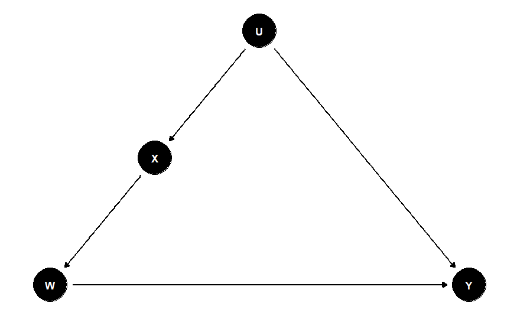

The problem is that `dagitty` does not know which variables we observe. Therefore R would consider $U$ to be a valid adjustment variable.

```
adjustmentSets(good, "W", "Y")
```

```
{ U }
{ X }
```

So far we did not encode in the graph definition which role a variable plays in our analysis. However, we can bake this information into the `dagitty` object by labeling

- treatment as `exposure`
- outcomes as `outcome`
- unobserved variables as `latent`

```
# DAG
good_specific = dagitty('dag{
                      X [pos = "0.5,0.5"]
                      U [latent, pos = "1,1"]
                      W [exposure, pos = "0,0"]
                      Y [outcome, pos = "2,0"]
                      U -> X
                      U -> Y
                      X -> W
                      X -> W
                      W -> Y}')
ggdag(good_specific) + theme_dag()
```

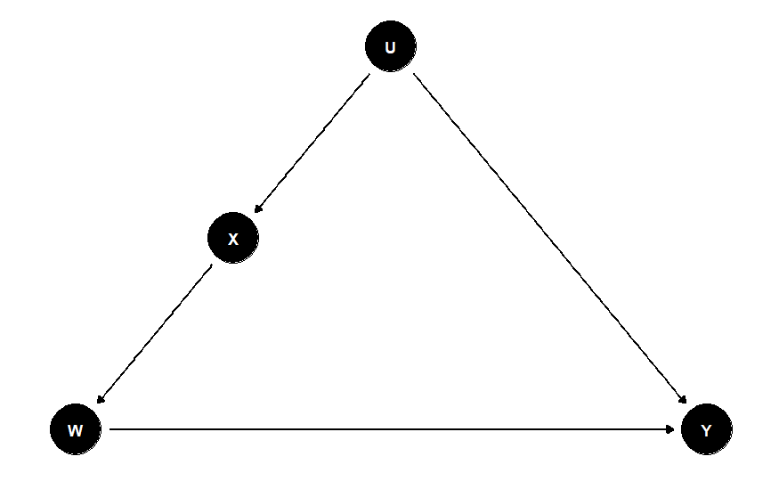

Then we need not to pass any information to the `adjustmentSets()` function as it already knows what we are interested in and what we observe:

```
adjustmentSets(good_specific)
```

```
{ X }
```

Now $U$ is not considered to be a valid adjustment set (if you would specify `type = "all"` it would still show up).

## M-bias

Implement the M-bias DAG from the lecture

```
# DAG
mbias = dagitty('dag{
                      X [pos = "0.5,0.5"]
                      U1 [latent,pos = "0,1"]
                      U2 [latent,pos = "1,1"]
                      W [exposure, pos = "0,0"]
                      Y [outcome, pos = "1,0"]
                      U1 -> X
                      U2 -> X
                      U1 -> W
                      U2 -> Y
                      W -> Y}')
ggdag(mbias) + theme_dag()
```

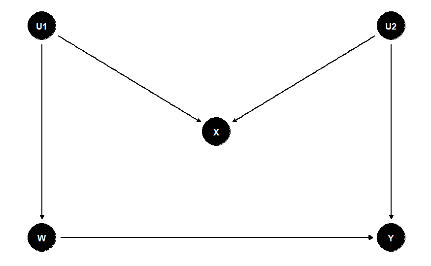

where a valid adjustment set requires NOT to condition on $X$ and therefore the adjustment set is the empty set.

```
adjustmentSets(mbias)
```

```
 {}
```

### Modified M-bias DAG

What happens if you add an edge from $X$ to $Y$?

```
# DAG
mbias_ext = dagitty('dag{
                      X [pos = "0.5,0.5"]
                      U1 [latent,pos = "0,1"]
                      U2 [latent,pos = "1,1"]
                      W [exposure, pos = "0,0"]
                      Y [outcome, pos = "1,0"]
                      U1 -> X
                      U2 -> X
                      U1 -> W
                      U2 -> Y
                      X -> Y
                      W -> Y}')
ggdag(mbias_ext) + theme_dag()
```

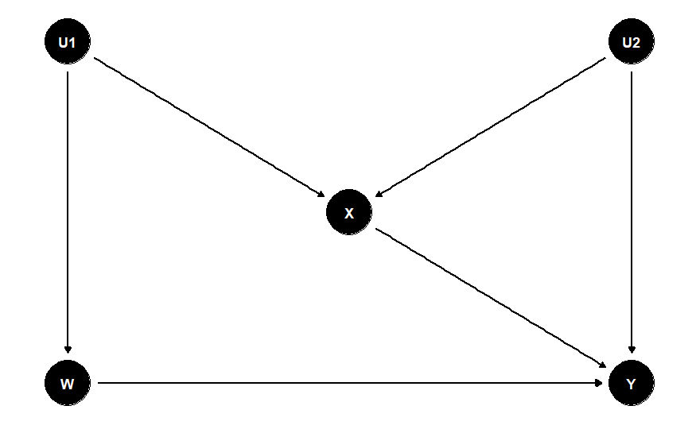

```
adjustmentSets(mbias_ext)
```

Observation: Not even the empty set is a valid adjustment set. Sadly, dagitty just does not print anything in this case, it is not broken.

Can you explain why?

We are in a dilemma. $\{\}$ leaves WU1XY open, while closing WU1XU2Y. On the other hand, $\{X\}$ closes WU1XY, while opening WU1XU2Y :-(

## (self-study) Implement the DAGs of slides 29-31 of the lecture and verify our conclusions